# Risk Factor Analysis

## Outcome Variable

**Outcome Variable:** pers_wast

## Predictor Variables

**Intervention Variable:** cleanck

**Adjustment Set:**

unadjusted

## Stratifying Variables

The analysis was stratified on these variable(s):

- agecat
- studyid
- country

## Data Summary

| agecat | studyid | country | cleanck | pers_wast | n_cell | n | outcome_variable |
| --- | --- | --- | --- | --- | --- | --- | --- |
| 0-24 months | ki0047075b-MAL-ED | PERU | 1 | 0 | 1 | 1 | pers_wast |
| 0-24 months | ki0047075b-MAL-ED | PERU | 1 | 1 | 0 | 1 | pers_wast |
| 0-24 months | ki0047075b-MAL-ED | PERU | 0 | 0 | 0 | 1 | pers_wast |
| 0-24 months | ki0047075b-MAL-ED | PERU | 0 | 1 | 0 | 1 | pers_wast |
| 0-24 months | ki0047075b-MAL-ED | SOUTH AFRICA | 1 | 0 | 1 | 2 | pers_wast |
| 0-24 months | ki0047075b-MAL-ED | SOUTH AFRICA | 1 | 1 | 0 | 2 | pers_wast |
| 0-24 months | ki0047075b-MAL-ED | SOUTH AFRICA | 0 | 0 | 1 | 2 | pers_wast |
| 0-24 months | ki0047075b-MAL-ED | SOUTH AFRICA | 0 | 1 | 0 | 2 | pers_wast |
| 0-24 months | ki1000108-CMC-V-BCS-2002 | INDIA | 1 | 0 | 157 | 373 | pers_wast |
| 0-24 months | ki1000108-CMC-V-BCS-2002 | INDIA | 1 | 1 | 6 | 373 | pers_wast |
| 0-24 months | ki1000108-CMC-V-BCS-2002 | INDIA | 0 | 0 | 193 | 373 | pers_wast |
| 0-24 months | ki1000108-CMC-V-BCS-2002 | INDIA | 0 | 1 | 17 | 373 | pers_wast |
| 0-24 months | ki1000108-IRC | INDIA | 1 | 0 | 204 | 400 | pers_wast |
| 0-24 months | ki1000108-IRC | INDIA | 1 | 1 | 27 | 400 | pers_wast |
| 0-24 months | ki1000108-IRC | INDIA | 0 | 0 | 148 | 400 | pers_wast |
| 0-24 months | ki1000108-IRC | INDIA | 0 | 1 | 21 | 400 | pers_wast |
| 0-24 months | ki1017093b-PROVIDE | BANGLADESH | 1 | 0 | 521 | 641 | pers_wast |
| 0-24 months | ki1017093b-PROVIDE | BANGLADESH | 1 | 1 | 9 | 641 | pers_wast |
| 0-24 months | ki1017093b-PROVIDE | BANGLADESH | 0 | 0 | 105 | 641 | pers_wast |
| 0-24 months | ki1017093b-PROVIDE | BANGLADESH | 0 | 1 | 6 | 641 | pers_wast |
| 0-24 months | ki1017093c-NIH-Crypto | BANGLADESH | 1 | 0 | 335 | 559 | pers_wast |
| 0-24 months | ki1017093c-NIH-Crypto | BANGLADESH | 1 | 1 | 8 | 559 | pers_wast |
| 0-24 months | ki1017093c-NIH-Crypto | BANGLADESH | 0 | 0 | 210 | 559 | pers_wast |
| 0-24 months | ki1017093c-NIH-Crypto | BANGLADESH | 0 | 1 | 6 | 559 | pers_wast |
| 0-24 months | ki1113344-GMS-Nepal | NEPAL | 1 | 0 | 8 | 534 | pers_wast |
| 0-24 months | ki1113344-GMS-Nepal | NEPAL | 1 | 1 | 1 | 534 | pers_wast |
| 0-24 months | ki1113344-GMS-Nepal | NEPAL | 0 | 0 | 454 | 534 | pers_wast |
| 0-24 months | ki1113344-GMS-Nepal | NEPAL | 0 | 1 | 71 | 534 | pers_wast |
| 0-6 months | ki0047075b-MAL-ED | PERU | 1 | 0 | 1 | 1 | pers_wast |
| 0-6 months | ki0047075b-MAL-ED | PERU | 1 | 1 | 0 | 1 | pers_wast |

[output cut: 54 more lines]

The following strata were considered:

- agecat: 0-24 months, studyid: ki0047075b-MAL-ED, country: PERU
- agecat: 0-24 months, studyid: ki0047075b-MAL-ED, country: SOUTH AFRICA
- agecat: 0-24 months, studyid: ki1000108-CMC-V-BCS-2002, country: INDIA
- agecat: 0-24 months, studyid: ki1000108-IRC, country: INDIA
- agecat: 0-24 months, studyid: ki1017093b-PROVIDE, country: BANGLADESH
- agecat: 0-24 months, studyid: ki1017093c-NIH-Crypto, country: BANGLADESH
- agecat: 0-24 months, studyid: ki1113344-GMS-Nepal, country: NEPAL
- agecat: 0-6 months, studyid: ki0047075b-MAL-ED, country: PERU
- agecat: 0-6 months, studyid: ki0047075b-MAL-ED, country: SOUTH AFRICA
- agecat: 0-6 months, studyid: ki1000108-CMC-V-BCS-2002, country: INDIA
- agecat: 0-6 months, studyid: ki1000108-IRC, country: INDIA
- agecat: 0-6 months, studyid: ki1017093b-PROVIDE, country: BANGLADESH
- agecat: 0-6 months, studyid: ki1017093c-NIH-Crypto, country: BANGLADESH
- agecat: 0-6 months, studyid: ki1113344-GMS-Nepal, country: NEPAL
- agecat: 6-24 months, studyid: ki0047075b-MAL-ED, country: PERU
- agecat: 6-24 months, studyid: ki0047075b-MAL-ED, country: SOUTH AFRICA
- agecat: 6-24 months, studyid: ki1000108-CMC-V-BCS-2002, country: INDIA
- agecat: 6-24 months, studyid: ki1000108-IRC, country: INDIA
- agecat: 6-24 months, studyid: ki1017093b-PROVIDE, country: BANGLADESH
- agecat: 6-24 months, studyid: ki1017093c-NIH-Crypto, country: BANGLADESH
- agecat: 6-24 months, studyid: ki1113344-GMS-Nepal, country: NEPAL

### Dropped Strata

Some strata were dropped due to rare outcomes:

- agecat: 0-24 months, studyid: ki0047075b-MAL-ED, country: PERU
- agecat: 0-24 months, studyid: ki0047075b-MAL-ED, country: SOUTH AFRICA
- agecat: 0-24 months, studyid: ki1113344-GMS-Nepal, country: NEPAL
- agecat: 0-6 months, studyid: ki0047075b-MAL-ED, country: PERU
- agecat: 0-6 months, studyid: ki0047075b-MAL-ED, country: SOUTH AFRICA
- agecat: 0-6 months, studyid: ki1017093b-PROVIDE, country: BANGLADESH
- agecat: 0-6 months, studyid: ki1017093c-NIH-Crypto, country: BANGLADESH
- agecat: 0-6 months, studyid: ki1113344-GMS-Nepal, country: NEPAL
- agecat: 6-24 months, studyid: ki0047075b-MAL-ED, country: PERU
- agecat: 6-24 months, studyid: ki0047075b-MAL-ED, country: SOUTH AFRICA
- agecat: 6-24 months, studyid: ki1113344-GMS-Nepal, country: NEPAL

## Methods Detail

We’re interested in the causal parameters $E[Y_a]$ for all values of $a \in \mathcal{A}$. These parameters represent the mean outcome if, possibly contrary to fact, we intervened to set all units to have $A=a$. Under the randomization and positivity assumptions, these are identified by the statistical parameters $\psi_a=E_W[E_{Y|A,W}(Y|A=a,W)]$. In addition, we’re interested in the mean of $Y$, $E[Y]$ under no intervention (the observed mean). We will estimate these parameters by using SuperLearner to fit the relevant likelihood factors – $E_{Y|A,W}(Y|A=a,W)$ and $p(A=a|W)$, and then updating our likelihood fit using a joint TMLE.

For unadjusted analyses ($W=\{\}$), initial likelihoods were estimated using Lrnr_glm to estimate the simple $E(Y|A)$ and Lrnr_mean to estimate $p(A)$. For adjusted analyses, a small library containing Lrnr_glmnet, Lrnr_xgboost, and Lrnr_mean was used.

Having estimated these parameters, we will then use the delta method to estimate relative risks and attributable risks relative to a prespecified baseline level of $A$.

# Results Detail

## Results Plots

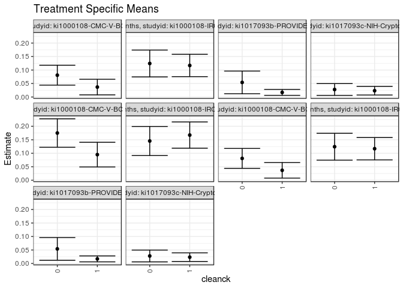

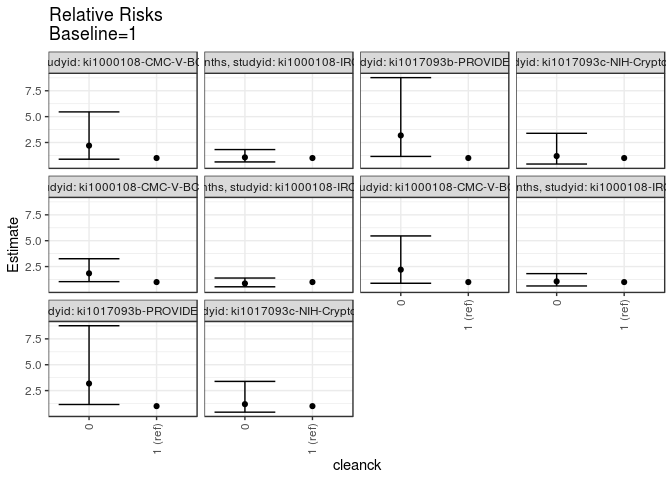

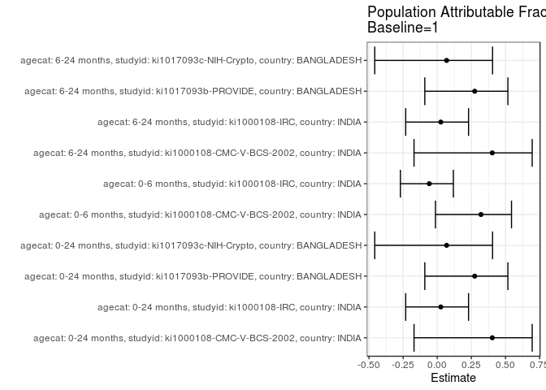

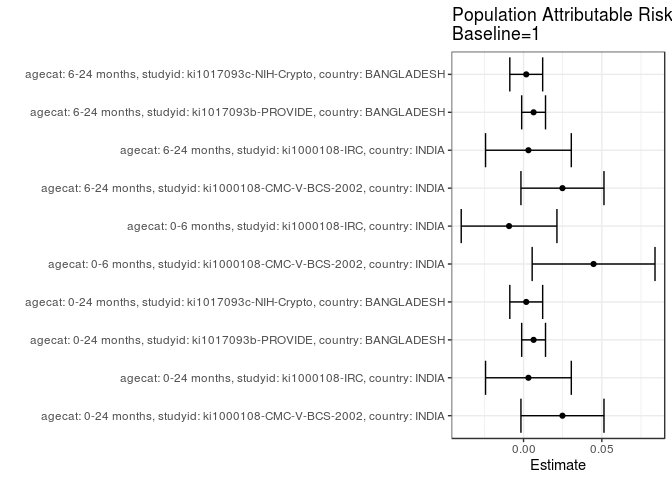

## Results Table

### Parameter: TSM

| agecat | studyid | country | intervention_level | baseline_level | estimate | ci_lower | ci_upper |
| --- | --- | --- | --- | --- | --- | --- | --- |
| 0-24 months | ki1000108-CMC-V-BCS-2002 | INDIA | 1 | NA | 0.0368098 | 0.0078647 | 0.0657549 |
| 0-24 months | ki1000108-CMC-V-BCS-2002 | INDIA | 0 | NA | 0.0809524 | 0.0440117 | 0.1178931 |
| 0-24 months | ki1000108-IRC | INDIA | 1 | NA | 0.1168831 | 0.0754001 | 0.1583662 |
| 0-24 months | ki1000108-IRC | INDIA | 0 | NA | 0.1242604 | 0.0744635 | 0.1740572 |
| 0-24 months | ki1017093b-PROVIDE | BANGLADESH | 1 | NA | 0.0169811 | 0.0059730 | 0.0279893 |
| 0-24 months | ki1017093b-PROVIDE | BANGLADESH | 0 | NA | 0.0540541 | 0.0119549 | 0.0961532 |
| 0-24 months | ki1017093c-NIH-Crypto | BANGLADESH | 1 | NA | 0.0233236 | 0.0073368 | 0.0393105 |
| 0-24 months | ki1017093c-NIH-Crypto | BANGLADESH | 0 | NA | 0.0277778 | 0.0058426 | 0.0497130 |
| 0-6 months | ki1000108-CMC-V-BCS-2002 | INDIA | 1 | NA | 0.0949367 | 0.0491664 | 0.1407070 |
| 0-6 months | ki1000108-CMC-V-BCS-2002 | INDIA | 0 | NA | 0.1750000 | 0.1222665 | 0.2277335 |
| 0-6 months | ki1000108-IRC | INDIA | 1 | NA | 0.1674009 | 0.1187729 | 0.2160289 |
| 0-6 months | ki1000108-IRC | INDIA | 0 | NA | 0.1454545 | 0.0915914 | 0.1993177 |
| 6-24 months | ki1000108-CMC-V-BCS-2002 | INDIA | 1 | NA | 0.0368098 | 0.0078647 | 0.0657549 |
| 6-24 months | ki1000108-CMC-V-BCS-2002 | INDIA | 0 | NA | 0.0809524 | 0.0440117 | 0.1178931 |
| 6-24 months | ki1000108-IRC | INDIA | 1 | NA | 0.1168831 | 0.0754001 | 0.1583662 |
| 6-24 months | ki1000108-IRC | INDIA | 0 | NA | 0.1242604 | 0.0744635 | 0.1740572 |
| 6-24 months | ki1017093b-PROVIDE | BANGLADESH | 1 | NA | 0.0169811 | 0.0059730 | 0.0279893 |
| 6-24 months | ki1017093b-PROVIDE | BANGLADESH | 0 | NA | 0.0540541 | 0.0119549 | 0.0961532 |
| 6-24 months | ki1017093c-NIH-Crypto | BANGLADESH | 1 | NA | 0.0233236 | 0.0073368 | 0.0393105 |
| 6-24 months | ki1017093c-NIH-Crypto | BANGLADESH | 0 | NA | 0.0277778 | 0.0058426 | 0.0497130 |

### Parameter: E(Y)

| agecat | studyid | country | intervention_level | baseline_level | estimate | ci_lower | ci_upper |
| --- | --- | --- | --- | --- | --- | --- | --- |
| 0-24 months | ki1000108-CMC-V-BCS-2002 | INDIA | NA | NA | 0.0616622 | 0.0372186 | 0.0861058 |
| 0-24 months | ki1000108-IRC | INDIA | NA | NA | 0.1200000 | 0.0881145 | 0.1518855 |
| 0-24 months | ki1017093b-PROVIDE | BANGLADESH | NA | NA | 0.0234009 | 0.0116889 | 0.0351130 |
| 0-24 months | ki1017093c-NIH-Crypto | BANGLADESH | NA | NA | 0.0250447 | 0.0120795 | 0.0380100 |
| 0-6 months | ki1000108-CMC-V-BCS-2002 | INDIA | NA | NA | 0.1396648 | 0.1037072 | 0.1756225 |
| 0-6 months | ki1000108-IRC | INDIA | NA | NA | 0.1581633 | 0.1219951 | 0.1943314 |
| 6-24 months | ki1000108-CMC-V-BCS-2002 | INDIA | NA | NA | 0.0616622 | 0.0372186 | 0.0861058 |
| 6-24 months | ki1000108-IRC | INDIA | NA | NA | 0.1200000 | 0.0881145 | 0.1518855 |
| 6-24 months | ki1017093b-PROVIDE | BANGLADESH | NA | NA | 0.0234009 | 0.0116889 | 0.0351130 |
| 6-24 months | ki1017093c-NIH-Crypto | BANGLADESH | NA | NA | 0.0250447 | 0.0120795 | 0.0380100 |

### Parameter: RR

| agecat | studyid | country | intervention_level | baseline_level | estimate | ci_lower | ci_upper |
| --- | --- | --- | --- | --- | --- | --- | --- |
| 0-24 months | ki1000108-CMC-V-BCS-2002 | INDIA | 1 | 1 | 1.0000000 | 1.0000000 | 1.000000 |
| 0-24 months | ki1000108-CMC-V-BCS-2002 | INDIA | 0 | 1 | 2.1992063 | 0.8859799 | 5.458937 |
| 0-24 months | ki1000108-IRC | INDIA | 1 | 1 | 1.0000000 | 1.0000000 | 1.000000 |
| 0-24 months | ki1000108-IRC | INDIA | 0 | 1 | 1.0631164 | 0.6224403 | 1.815783 |
| 0-24 months | ki1017093b-PROVIDE | BANGLADESH | 1 | 1 | 1.0000000 | 1.0000000 | 1.000000 |
| 0-24 months | ki1017093b-PROVIDE | BANGLADESH | 0 | 1 | 3.1831830 | 1.1555326 | 8.768817 |
| 0-24 months | ki1017093c-NIH-Crypto | BANGLADESH | 1 | 1 | 1.0000000 | 1.0000000 | 1.000000 |
| 0-24 months | ki1017093c-NIH-Crypto | BANGLADESH | 0 | 1 | 1.1909722 | 0.4185803 | 3.388632 |
| 0-6 months | ki1000108-CMC-V-BCS-2002 | INDIA | 1 | 1 | 1.0000000 | 1.0000000 | 1.000000 |
| 0-6 months | ki1000108-CMC-V-BCS-2002 | INDIA | 0 | 1 | 1.8433333 | 1.0439767 | 3.254744 |
| 0-6 months | ki1000108-IRC | INDIA | 1 | 1 | 1.0000000 | 1.0000000 | 1.000000 |
| 0-6 months | ki1000108-IRC | INDIA | 0 | 1 | 0.8688995 | 0.5427106 | 1.391140 |
| 6-24 months | ki1000108-CMC-V-BCS-2002 | INDIA | 1 | 1 | 1.0000000 | 1.0000000 | 1.000000 |
| 6-24 months | ki1000108-CMC-V-BCS-2002 | INDIA | 0 | 1 | 2.1992063 | 0.8859799 | 5.458937 |
| 6-24 months | ki1000108-IRC | INDIA | 1 | 1 | 1.0000000 | 1.0000000 | 1.000000 |
| 6-24 months | ki1000108-IRC | INDIA | 0 | 1 | 1.0631164 | 0.6224403 | 1.815783 |
| 6-24 months | ki1017093b-PROVIDE | BANGLADESH | 1 | 1 | 1.0000000 | 1.0000000 | 1.000000 |
| 6-24 months | ki1017093b-PROVIDE | BANGLADESH | 0 | 1 | 3.1831830 | 1.1555326 | 8.768817 |
| 6-24 months | ki1017093c-NIH-Crypto | BANGLADESH | 1 | 1 | 1.0000000 | 1.0000000 | 1.000000 |
| 6-24 months | ki1017093c-NIH-Crypto | BANGLADESH | 0 | 1 | 1.1909722 | 0.4185803 | 3.388632 |

### Parameter: PAR

| agecat | studyid | country | intervention_level | baseline_level | estimate | ci_lower | ci_upper |
| --- | --- | --- | --- | --- | --- | --- | --- |
| 0-24 months | ki1000108-CMC-V-BCS-2002 | INDIA | 1 | NA | 0.0248524 | -0.0016629 | 0.0513677 |
| 0-24 months | ki1000108-IRC | INDIA | 1 | NA | 0.0031169 | -0.0242684 | 0.0305022 |
| 0-24 months | ki1017093b-PROVIDE | BANGLADESH | 1 | NA | 0.0064198 | -0.0011934 | 0.0140331 |
| 0-24 months | ki1017093c-NIH-Crypto | BANGLADESH | 1 | NA | 0.0017211 | -0.0087685 | 0.0122108 |
| 0-6 months | ki1000108-CMC-V-BCS-2002 | INDIA | 1 | NA | 0.0447281 | 0.0055015 | 0.0839547 |
| 0-6 months | ki1000108-IRC | INDIA | 1 | NA | -0.0092376 | -0.0398012 | 0.0213259 |
| 6-24 months | ki1000108-CMC-V-BCS-2002 | INDIA | 1 | NA | 0.0248524 | -0.0016629 | 0.0513677 |
| 6-24 months | ki1000108-IRC | INDIA | 1 | NA | 0.0031169 | -0.0242684 | 0.0305022 |
| 6-24 months | ki1017093b-PROVIDE | BANGLADESH | 1 | NA | 0.0064198 | -0.0011934 | 0.0140331 |
| 6-24 months | ki1017093c-NIH-Crypto | BANGLADESH | 1 | NA | 0.0017211 | -0.0087685 | 0.0122108 |

### Parameter: PAF

| agecat | studyid | country | intervention_level | baseline_level | estimate | ci_lower | ci_upper |
| --- | --- | --- | --- | --- | --- | --- | --- |
| 0-24 months | ki1000108-CMC-V-BCS-2002 | INDIA | 1 | NA | 0.4030408 | -0.1700513 | 0.6954319 |
| 0-24 months | ki1000108-IRC | INDIA | 1 | NA | 0.0259740 | -0.2310909 | 0.2293611 |
| 0-24 months | ki1017093b-PROVIDE | BANGLADESH | 1 | NA | 0.2743396 | -0.0912317 | 0.5174416 |
| 0-24 months | ki1017093c-NIH-Crypto | BANGLADESH | 1 | NA | 0.0687214 | -0.4579033 | 0.4051184 |
| 0-6 months | ki1000108-CMC-V-BCS-2002 | INDIA | 1 | NA | 0.3202531 | -0.0131212 | 0.5439284 |
| 0-6 months | ki1000108-IRC | INDIA | 1 | NA | -0.0584056 | -0.2700772 | 0.1179888 |
| 6-24 months | ki1000108-CMC-V-BCS-2002 | INDIA | 1 | NA | 0.4030408 | -0.1700513 | 0.6954319 |
| 6-24 months | ki1000108-IRC | INDIA | 1 | NA | 0.0259740 | -0.2310909 | 0.2293611 |
| 6-24 months | ki1017093b-PROVIDE | BANGLADESH | 1 | NA | 0.2743396 | -0.0912317 | 0.5174416 |
| 6-24 months | ki1017093c-NIH-Crypto | BANGLADESH | 1 | NA | 0.0687214 | -0.4579033 | 0.4051184 |